# 111-1 R Fundamentals

Jakey BLUE

August 29, 2022

## What is R?

- R is a free, cross-platform and open source programming language designed by Ross Ihaka and Robert Gentleman in 1993. Its forerunner is S language, or known as S-PLUS.
- R works like normal programming languages such as Python, Perl and Java. It also serves as a powerful statistical tool like SAS, SPSS, MATLAB.
- R displays data visualization conveniently and has extensive packages in doing all kinds of analyses.

## How do we start?

- Installing R: https://cloud.r-project.org/index.html, select the closer mirror and download the latest version (R 4.2.1 released on Jun. 23, 2022).
- Popular R IDE: [RStudio](https://www.rstudio.com/products/rstudio/download/), Tinn-R, Notepad++ (with add-on NppToR), or any text editor (save as .R file).
- Practice all the following commands. If you want to learn unknown functions or packages, **Google them**, or **LSGTFY**.

## Getting familiar with data types and operations (Variable, Vector, Matrix, Array, and List)

#### Assign values to variables and remove the variables.

```r
x <- 3
x
```

```
## [1] 3
```

```r
y = 5
z <- x * y
z
```

```
## [1] 15
```

```r
rm(x)
remove(y, z)
```

#### Vector is of one dimension with the same data type.

```r
x <- c(1, 2, 3, 4, 5)
x[2]
```

```
## [1] 2
```

```r
y <- c("Hello", "R", 'World')
y
```

```
## [1] "Hello" "R"     "World"
```

```r
paste(y[1], y[3], x[4], "You")
```

```
## [1] "Hello World 4 You"
```

#### Vector can be operated as an integrated unit.

```r
x + 2
```

```
## [1] 3 4 5 6 7
```

```r
x / 10
```

```
## [1] 0.1 0.2 0.3 0.4 0.5
```

```r
x ^ 2
```

```
## [1]  1  4  9 16 25
```

#### Create vectors with specific patterns using convenient operators or functions

```r
x <- c(1:10)
z <- c(-5:4)
z
```

```
##  [1] -5 -4 -3 -2 -1  0  1  2  3  4
```

```r
x - z
```

```
##  [1] 6 6 6 6 6 6 6 6 6 6
```

```r
x ^ z
```

```
##  [1] 1.000000e+00 6.250000e-02 3.703704e-02 6.250000e-02 2.000000e-01
##  [6] 1.000000e+00 7.000000e+00 6.400000e+01 7.290000e+02 1.000000e+04
```

#### Check the properties of a vector or object.

```r
mode(y)
```

```
## [1] "character"
```

```r
length(y)
```

```
## [1] 3
```

```r
length(x)
```

```
## [1] 10
```

#### Factor = Vector with levels, treated as categorical data.

```r
x <- c(1, 4, 3, 2, 4, 3, 4, 3, 2, 1)
factor(x)
```

```
##  [1] 1 4 3 2 4 3 4 3 2 1
## Levels: 1 2 3 4
```

```r
factor(x, labels = c('un', 'deux', 'trois', 'quatre'))
```

```
##  [1] un     quatre trois  deux   quatre trois  quatre trois  deux   un
## Levels: un deux trois quatre
```

```r
factor(x, ordered = TRUE)
```

```
##  [1] 1 4 3 2 4 3 4 3 2 1
## Levels: 1 < 2 < 3 < 4
```

#### Set up a Matrix with TWO dimensions.

```r
aMX <- matrix(1:12, nrow = 4, ncol = 3)
aMX
```

```
##      [,1] [,2] [,3]
## [1,]    1    5    9
## [2,]    2    6   10
## [3,]    3    7   11
## [4,]    4    8   12
```

#### Set up an Array with MULTI-dimensions.

```r
anAR <- array(1:12, dim = c(2, 3, 2))
anAR
```

```
## , , 1
##
##      [,1] [,2] [,3]
## [1,]    1    3    5
## [2,]    2    4    6
##
## , , 2
##
##      [,1] [,2] [,3]
## [1,]    7    9   11
## [2,]    8   10   12
```

#### Create a Data.Frame to include different data types among columns.

```r
aDF <- data.frame(id = 1:5, scores = c(11, 10, 13, 14, 19), GPA = c("C", "C", "B", "B", "A"))
aDF
```

```
##   id scores GPA
## 1  1     11   C
## 2  2     10   C
## 3  3     13   B
## 4  4     14   B
## 5  5     19   A
```

```r
colnames(aDF)
```

```
## [1] "id"     "scores" "GPA"
```

```r
# The column is in effect a factor.
aDF$GPA
```

```
## [1] C C B B A
## Levels: A B C
```

```r
# Subsetting a DataFrame is extremely useful.
aDF[which(aDF$GPA == "B"),]
```

```
##   id scores GPA
## 3  3     13   B
## 4  4     14   B
```

```r
# Another way to subset a DataFrame.
subset(aDF, aDF$scores > 12)
```

```
##   id scores GPA
## 3  3     13   B
## 4  4     14   B
## 5  5     19   A
```

#### List can link any types of variables or objects together. Be cautious with the indexing operator [].

```r
aLT <- list(x, y, anAR, aMX)
aLT[1]
```

```
## [[1]]
##  [1] 1 4 3 2 4 3 4 3 2 1
```

```r
aLT[[2]][3]
```

```
## [1] "World"
```

```r
aLT[[3]][,,1]
```

```
##      [,1] [,2] [,3]
## [1,]    1    3    5
## [2,]    2    4    6
```

#### Check the data type and the structure of a variable.

```r
str(x)
```

```
##  num [1:10] 1 4 3 2 4 3 4 3 2 1
```

```r
str(anAR)
```

```
##  int [1:2, 1:3, 1:2] 1 2 3 4 5 6 7 8 9 10 ...
```

```r
str(aMX)
```

```
##  int [1:4, 1:3] 1 2 3 4 5 6 7 8 9 10 ...
```

```r
str(aDF)
```

```
## 'data.frame':    5 obs. of  3 variables:
##  $ id    : int  1 2 3 4 5
##  $ scores: num  11 10 13 14 19
##  $ GPA   : Factor w/ 3 levels "A","B","C": 3 3 2 2 1
```

```r
str(aLT)
```

```
## List of 4
##  $ : num [1:10] 1 4 3 2 4 3 4 3 2 1
##  $ : chr [1:3] "Hello" "R" "World"
##  $ : int [1:2, 1:3, 1:2] 1 2 3 4 5 6 7 8 9 10 ...
##  $ : int [1:4, 1:3] 1 2 3 4 5 6 7 8 9 10 ...
```

#### Merge two vectors and perform the matrix algebra.

```r
# cbind is for column binding, try rbind() to know what happens
xz <- cbind(x, z)
str(xz)
```

```
##  num [1:10, 1:2] 1 4 3 2 4 3 4 3 2 1 ...
##  - attr(*, "dimnames")=List of 2
##   ..$ : NULL
##   ..$ : chr [1:2] "x" "z"
```

```r
xz %*% c(5, 1)
```

```
##       [,1]
##  [1,]    0
##  [2,]   16
##  [3,]   12
##  [4,]    8
##  [5,]   19
##  [6,]   15
##  [7,]   21
##  [8,]   17
##  [9,]   13
## [10,]    9
```

## Using Functions

#### Calculate fundamental descriptive statistics.

```r
mean(x, na.rm = FALSE)
```

```
## [1] 2.7
```

```r
var(aDF$scores)
```

```
## [1] 12.3
```

```r
quantile(x)
```

```
##   0%  25%  50%  75% 100%
## 1.00 2.00 3.00 3.75 4.00
```

```r
cov(x[4:8], aDF$scores)
```

```
## [1] -0.1
```

#### Generate random data according to a given distribution.

```r
# Random variable following a normal distribution with mean 42 and standard deviation 10.
rv_normal <- rnorm(20, 42, 10)
# Random variable following a uniform distribution with min 0 and max 20.
rv_uniform <- runif(20, 0, 20)
# Random variable following a chi-squared distribution with degrees of freedom 10.
rv_chi2 <- rchisq(20, 10)
# Random sample from "F" or "T" is actually following a Bernoulli distribution.
rv_bool <- sample(c("F", "T"), 20, replace = TRUE)
# Put all the random variables into one data.frame.
randomDF <- data.frame(BoolRV = rv_bool, NormRV = rv_normal, UniRV = rv_uniform, Chi2RV = rv_chi2)
summary(randomDF)
```

```
##  BoolRV     NormRV          UniRV            Chi2RV
##  F: 7   Min.   :27.61   Min.   : 1.007   Min.   : 3.001
##  T:13   1st Qu.:36.26   1st Qu.: 5.189   1st Qu.: 7.669
##         Median :43.79   Median : 8.227   Median :11.849
##         Mean   :42.97   Mean   :10.472   Mean   :11.231
##         3rd Qu.:50.16   3rd Qu.:16.102   3rd Qu.:13.901
##         Max.   :56.58   Max.   :19.828   Max.   :21.766
```

#### Summarize a dataset.

```r
summary(aDF)
```

```
##        id        scores     GPA
##  Min.   :1   Min.   :10.0   A:1
##  1st Qu.:2   1st Qu.:11.0   B:2
##  Median :3   Median :13.0   C:2
##  Mean   :3   Mean   :13.4
##  3rd Qu.:4   3rd Qu.:14.0
##  Max.   :5   Max.   :19.0
```

```r
tapply(aDF$scores, aDF$GPA, mean)
```

```
##    A    B    C
## 19.0 13.5 10.5
```

```r
# Using attach-detach to simplify the redundant commands.
attach(aDF)
tapply(scores, GPA, mean)
```

```
##    A    B    C
## 19.0 13.5 10.5
```

```r
detach(aDF)
```

#### Check a default dataset in R: mtcars https://stat.ethz.ch/R-manual/R-devel/library/datasets/html/mtcars.html

- A data frame with 32 observations on 11 variables.

  [, 1] mpg Miles/(US) gallon  
  [, 2] cyl Number of cylinders  
  [, 3] disp Displacement (cu.in.)  
  [, 4] hp Gross horsepower  
  [, 5] drat Rear axle ratio  
  [, 6] wt Weight (1000 lbs)  
  [, 7] qsec 1/4 mile time  
  [, 8] vs V/S  
  [, 9] am Transmission (0 = automatic, 1 = manual)  
  [,10] gear Number of forward gears  
  [,11] carb Number of carburetors

```r
attach(mtcars)
summary(mtcars)
```

```
##       mpg             cyl             disp             hp
##  Min.   :10.40   Min.   :4.000   Min.   : 71.1   Min.   : 52.0
##  1st Qu.:15.43   1st Qu.:4.000   1st Qu.:120.8   1st Qu.: 96.5
##  Median :19.20   Median :6.000   Median :196.3   Median :123.0
##  Mean   :20.09   Mean   :6.188   Mean   :230.7   Mean   :146.7
##  3rd Qu.:22.80   3rd Qu.:8.000   3rd Qu.:326.0   3rd Qu.:180.0
##  Max.   :33.90   Max.   :8.000   Max.   :472.0   Max.   :335.0
##       drat             wt             qsec             vs
##  Min.   :2.760   Min.   :1.513   Min.   :14.50   Min.   :0.0000
##  1st Qu.:3.080   1st Qu.:2.581   1st Qu.:16.89   1st Qu.:0.0000
##  Median :3.695   Median :3.325   Median :17.71   Median :0.0000
##  Mean   :3.597   Mean   :3.217   Mean   :17.85   Mean   :0.4375
##  3rd Qu.:3.920   3rd Qu.:3.610   3rd Qu.:18.90   3rd Qu.:1.0000
##  Max.   :4.930   Max.   :5.424   Max.   :22.90   Max.   :1.0000
##        am              gear            carb
##  Min.   :0.0000   Min.   :3.000   Min.   :1.000
##  1st Qu.:0.0000   1st Qu.:3.000   1st Qu.:2.000
##  Median :0.0000   Median :4.000   Median :2.000
##  Mean   :0.4062   Mean   :3.688   Mean   :2.812
##  3rd Qu.:1.0000   3rd Qu.:4.000   3rd Qu.:4.000
##  Max.   :1.0000   Max.   :5.000   Max.   :8.000
```

```r
# Correlation among the variables
cor(mtcars[,1:6], method = "pearson")
```

```
##             mpg        cyl       disp         hp       drat         wt
## mpg   1.0000000 -0.8521620 -0.8475514 -0.7761684  0.6811719 -0.8676594
## cyl  -0.8521620  1.0000000  0.9020329  0.8324475 -0.6999381  0.7824958
## disp -0.8475514  0.9020329  1.0000000  0.7909486 -0.7102139  0.8879799
## hp   -0.7761684  0.8324475  0.7909486  1.0000000 -0.4487591  0.6587479
## drat  0.6811719 -0.6999381 -0.7102139 -0.4487591  1.0000000 -0.7124406
## wt   -0.8676594  0.7824958  0.8879799  0.6587479 -0.7124406  1.0000000
```

```r
# Average mpg in terms of transmission (0 = auto, 1 = manual)
tapply(mpg, am, mean)
```

```
##        0        1
## 17.14737 24.39231
```

There is no easy function to summarize multiple variables by groups.  
We will need other package to help, such as “dplyr”.  
You can use the commend: install.packages(“dplyr”) to install the package into R.

```r
# To use the package, we have to include it firstly.
library("dplyr")
summarise(group_by(mtcars, am),
          mpg_mean = mean(mpg),
          mpg_var = var(mpg),
          hp_mean = mean(hp),
          wt_mean = mean(wt),
          gear_mean = mean(gear))
```

```
## # A tibble: 2 × 6
##      am mpg_mean mpg_var hp_mean wt_mean gear_mean
##   <dbl>    <dbl>   <dbl>   <dbl>   <dbl>     <dbl>
## 1     0     17.1    14.7    160.    3.77      3.21
## 2     1     24.4    38.0    127.    2.41      4.38
```

#### Define a function and use it.

```r
# Define a logistic function and get some returns
logi <- function(x){
  return (1 / (1 + exp(-x)))
}
logi(0)
```

```
## [1] 0.5
```

```r
logi(-6:6)
```

```
##  [1] 0.002472623 0.006692851 0.017986210 0.047425873 0.119202922 0.268941421
##  [7] 0.500000000 0.731058579 0.880797078 0.952574127 0.982013790 0.993307149
## [13] 0.997527377
```

## Including Plots

#### Plot the function

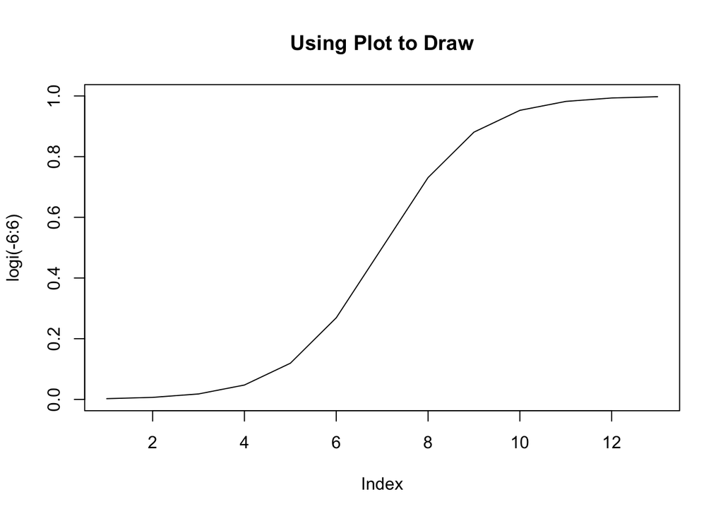

```r
plot(logi(-6:6), type = "l", main = "Using Plot to Draw")
```

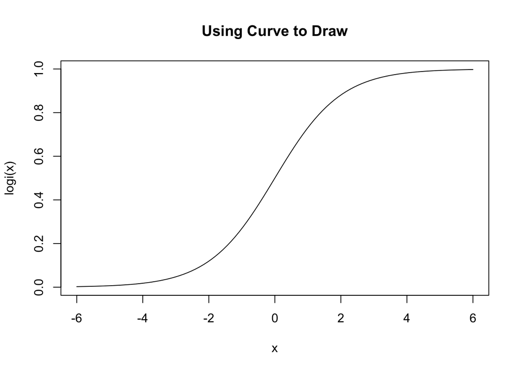

```r
curve(logi, from = -6, to = 6, main = "Using Curve to Draw")
```

#### Plots of single variable.

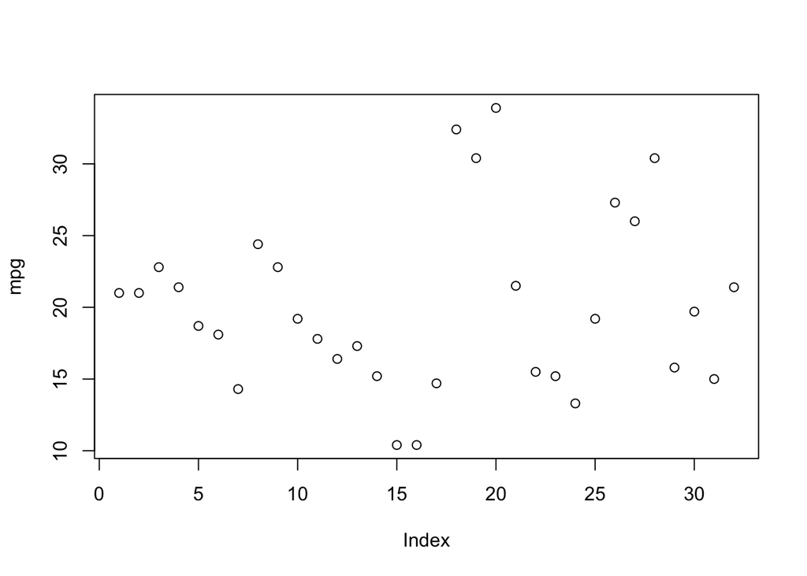

```r
plot(mpg)
```

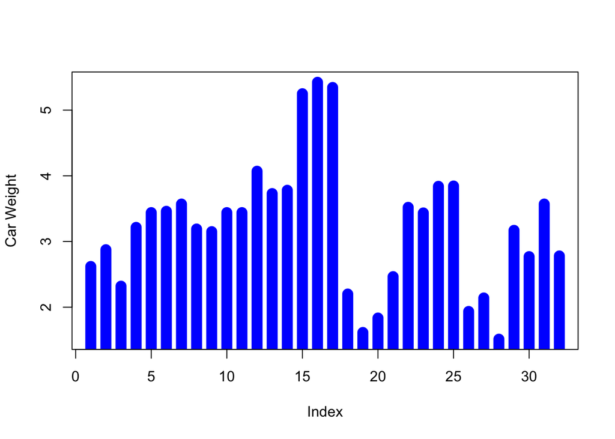

```r
plot(wt, type = "h", col = "blue", lwd = 12, ylab = "Car Weight")   # barplot() can work equivalently
```

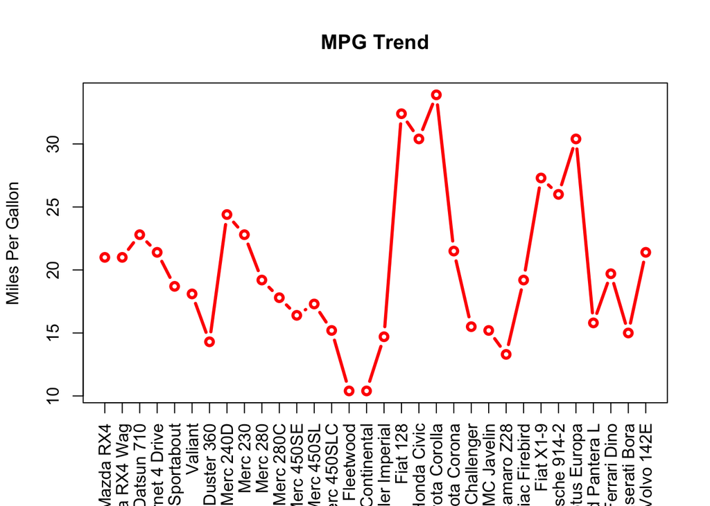

```r
# A more advanced way plotting mpg with respect to their car model.
plot(mpg, type = "b", col = "red", lwd = 3, xlab = "", xaxt= "n", ylab = "Miles Per Gallon", main = "MPG Trend")
axis(side = 1, at = 1:32, labels = rownames(mtcars), las = 2)
```

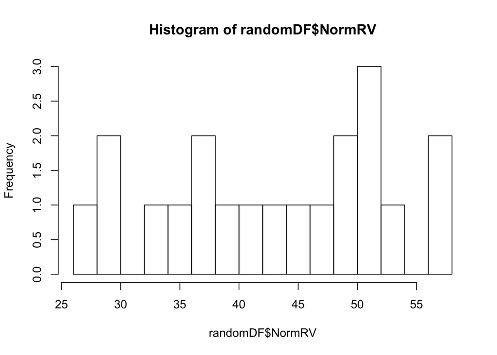

```r
# Histogram is within a simple function.
hist(randomDF$NormRV, breaks = 20)
```

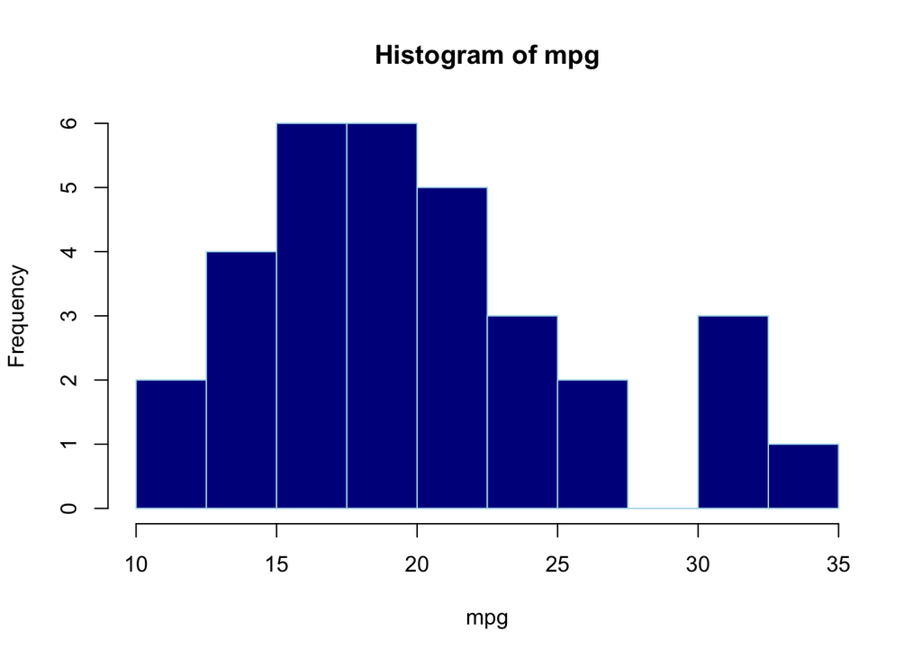

```r
hist(mpg, breaks = seq(10, 35, 2.5), col = "darkblue", border = "lightblue")
```

#### Plots among multiple variables.

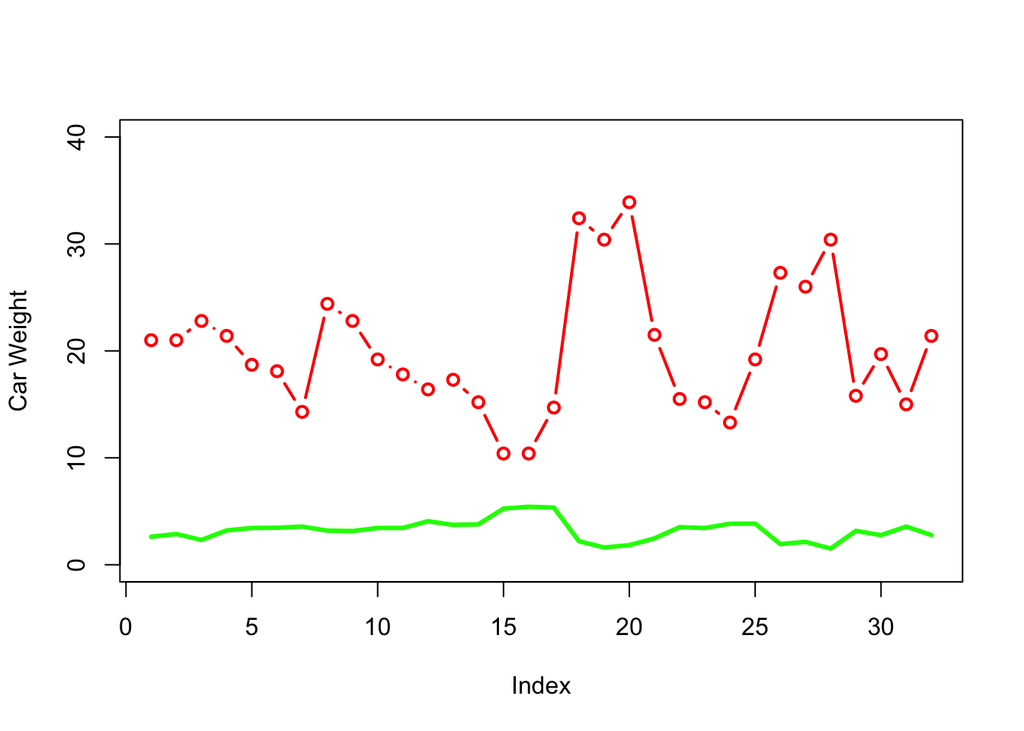

```r
# To draw two data series on one plot, you need at least two lines of commands.
plot(mpg, type = "b", col = "red", lwd = 2, ylab = "Car Weight", ylim = c(0, 40))
lines(wt, type = "l", col = "green", lwd = 3)
```

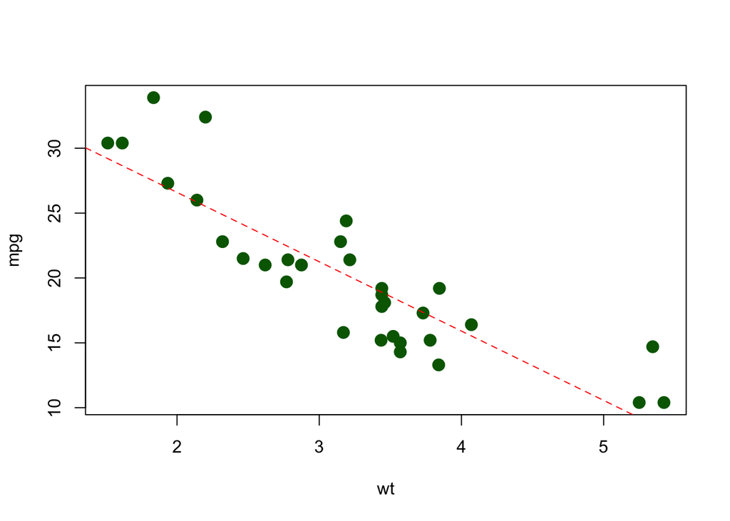

```r
# pch = point symbol, check: http://www.statmethods.net/advgraphs/parameters.html
# cex = point size
plot(mpg ~ wt, pch = 19, cex = 1.5, col = "darkgreen")
# We can also add a fitted regression line
abline(lm(mpg ~ wt), lty = 2, col = "red")
```

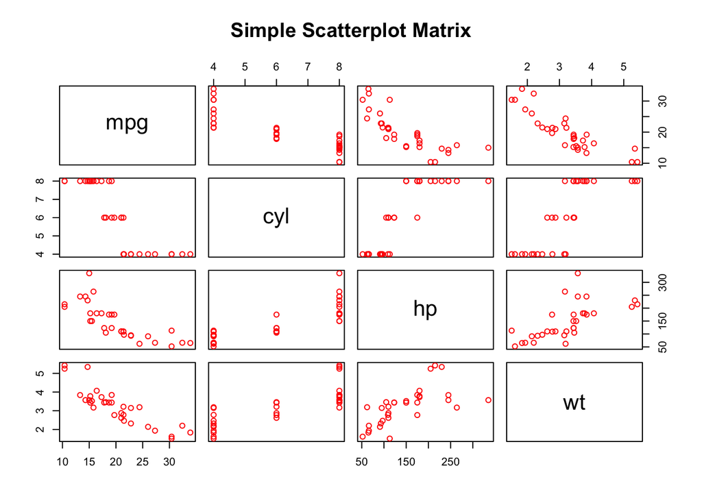

```r
# A matrix of scatter plots can show all information at once.
pairs(mtcars[,c(1, 2, 4, 6)], col = "red", main = "Simple Scatterplot Matrix")
```

#### Draw a Boxplot

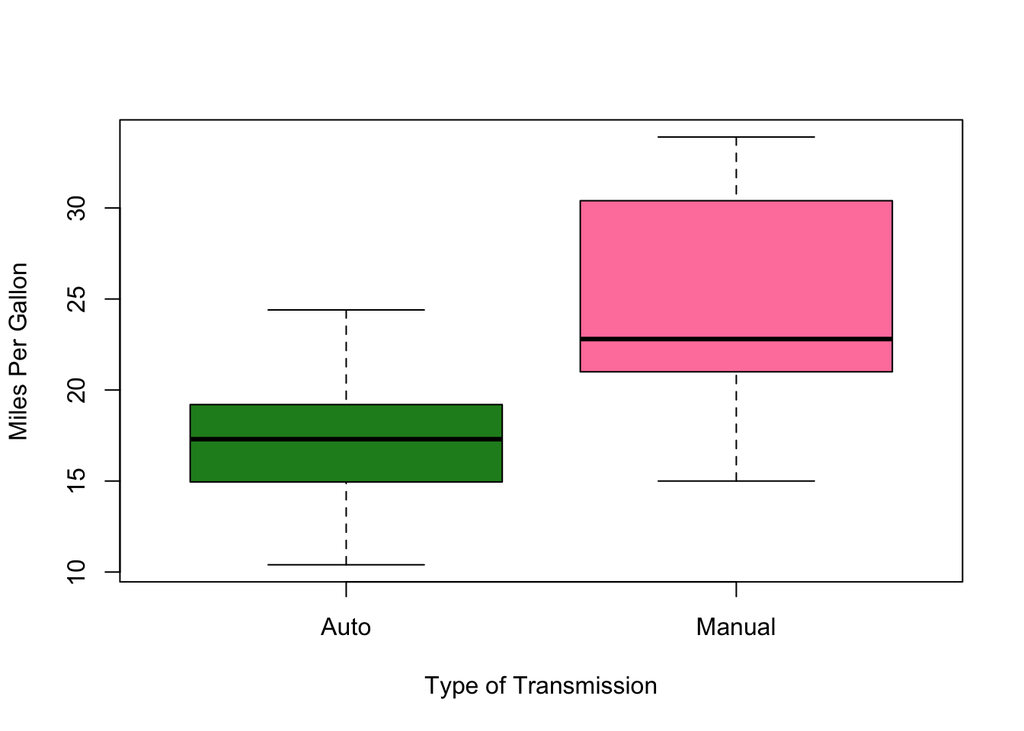

```r
boxplot(mpg ~ am, col = c("forestgreen","palevioletred1"), names = c("Auto", "Manual"), xlab = "Type of Transmission", ylab = "Miles Per Gallon")
```

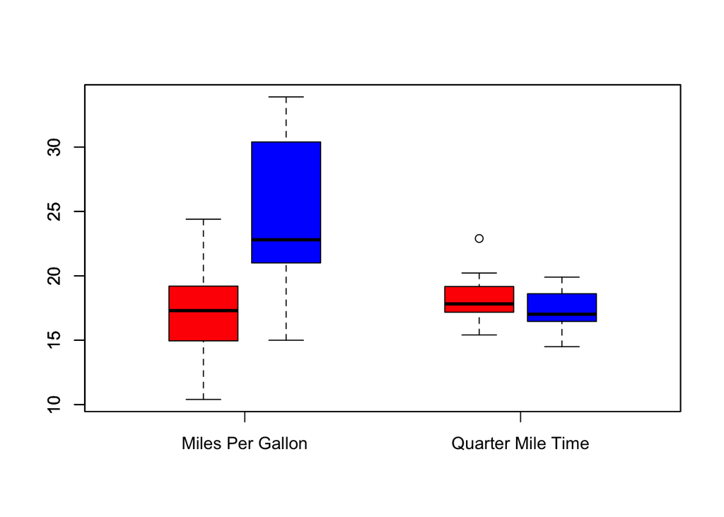

```r
# To draw two variables and compare their boxplots takes some tricks.
boxplot(mtcars[, c(1, 7)], xlim = c(0.5, 2.5), names = c("Miles Per Gallon", "Quarter Mile Time"), boxfill = rgb(1, 1, 1, alpha = 1), border = rgb(1, 1, 1, alpha = 1))
boxplot(mtcars[which(am == 0), c(1, 7)], xaxt = "n", add = TRUE, boxfill = "red", boxwex = 0.25, at = c(0.85, 1.85))
boxplot(mtcars[which(am == 1), c(1, 7)], xaxt = "n", add = TRUE, boxfill = "blue", boxwex = 0.25, at = c(1.15, 2.15))
```

## What Else?

- You can create a .R file to proceed a series of commands.
- You can import datasets in the files or connect to a database directly in R.
- Check “par” https://stat.ethz.ch/R-manual/R-devel/library/graphics/html/par.html in R help to learn more about the multi-plotting, which is a very useful function of data visualization in R.
- Don’t forget R is a programming language. You can also use looping statements and logic operators to complie complex algorithms.

## Now your turn to solve the following exercises.

1. Simulate 1~5 dices (with 6 faces each die), i.e., 1~5 random variables, in order to see if the average of 1~5 dices will eventually follow a normal distribution, which can be observed in histograms. This is to illustrate how the `Central Limit Theorem` works.
2. Take a look at the default “iris” dataset in R (https://stat.ethz.ch/R-manual/R-devel/library/datasets/html/iris.html). Get a summary table/matrix over iris dataset (`mean`, `variance`, `correlation matrix`).

[figure not shown]

3. Make a 3 by 4 matrix of “histograms” in terms of the three species: `setosa`, `versicolor`, `virginica`. You will need to look for helpful packages or learn how to use the looping statement.
4. Compare the boxplots of the three species under each of the four variables: `Sepal.Length`, `Sepal.Width`, `Petal.Length`, `Petal.Width`.
5. Learn what is a `Normal Probabilty plot` (also known as `Q-Q plot`) and draw four Q-Q plots for iris variables.

## END of Practice

```r
# Clean up all the variables occupied in the computer memory.
rm(aDF, aMX, randomDF, aLT, anAR, rv_bool, rv_chi2, rv_normal, rv_uniform, y, z)
```